# Project 5: Communicate Data Findings (2017 Ford Gobike Dataset)

## Preliminary Wrangling

```python
# import all packages and set plots to be embedded inline
import numpy as np
import pandas as pd
import matplotlib.pyplot as plt
import seaborn as sb

%matplotlib inline
```

> Load in your dataset and describe its properties through the questions below. Try and motivate your exploration goals through this section.

```python
df = pd.read_csv('2017-fordgobike-tripdata.csv')
df.head()
```

|  | duration_sec | start_time | end_time | start_station_id | start_station_name | start_station_latitude | start_station_longitude | end_station_id | end_station_name | end_station_latitude | end_station_longitude | bike_id | user_type |
| --- | --- | --- | --- | --- | --- | --- | --- | --- | --- | --- | --- | --- | --- |
| 0 | 80110 | 2017-12-31 16:57:39.6540 | 2018-01-01 15:12:50.2450 | 74 | Laguna St at Hayes St | 37.776435 | -122.426244 | 43 | San Francisco Public Library (Grove St at Hyde... | 37.778768 | -122.415929 | 96 | Customer |
| 1 | 78800 | 2017-12-31 15:56:34.8420 | 2018-01-01 13:49:55.6170 | 284 | Yerba Buena Center for the Arts (Howard St at ... | 37.784872 | -122.400876 | 96 | Dolores St at 15th St | 37.766210 | -122.426614 | 88 | Customer |
| 2 | 45768 | 2017-12-31 22:45:48.4110 | 2018-01-01 11:28:36.8830 | 245 | Downtown Berkeley BART | 37.870348 | -122.267764 | 245 | Downtown Berkeley BART | 37.870348 | -122.267764 | 1094 | Customer |
| 3 | 62172 | 2017-12-31 17:31:10.6360 | 2018-01-01 10:47:23.5310 | 60 | 8th St at Ringold St | 37.774520 | -122.409449 | 5 | Powell St BART Station (Market St at 5th St) | 37.783899 | -122.408445 | 2831 | Customer |
| 4 | 43603 | 2017-12-31 14:23:14.0010 | 2018-01-01 02:29:57.5710 | 239 | Bancroft Way at Telegraph Ave | 37.868813 | -122.258764 | 247 | Fulton St at Bancroft Way | 37.867789 | -122.265896 | 3167 | Subscriber |

```python
df.shape
```

```
(519700, 13)
```

```python
df.describe()
```

|  | duration_sec | start_station_id | start_station_latitude | start_station_longitude | end_station_id | end_station_latitude | end_station_longitude | bike_id |
| --- | --- | --- | --- | --- | --- | --- | --- | --- |
| count | 519700.000000 | 519700.000000 | 519700.000000 | 519700.000000 | 519700.000000 | 519700.000000 | 519700.000000 | 519700.000000 |
| mean | 1099.009521 | 95.034245 | 37.771653 | -122.363927 | 92.184041 | 37.771844 | -122.363236 | 1672.533079 |
| std | 3444.146451 | 86.083078 | 0.086305 | 0.105573 | 84.969491 | 0.086224 | 0.105122 | 971.356959 |
| min | 61.000000 | 3.000000 | 37.317298 | -122.444293 | 3.000000 | 37.317298 | -122.444293 | 10.000000 |
| 25% | 382.000000 | 24.000000 | 37.773492 | -122.411726 | 23.000000 | 37.774520 | -122.410345 | 787.000000 |
| 50% | 596.000000 | 67.000000 | 37.783521 | -122.398870 | 66.000000 | 37.783830 | -122.398525 | 1728.500000 |
| 75% | 938.000000 | 139.000000 | 37.795392 | -122.391034 | 134.000000 | 37.795392 | -122.391034 | 2520.000000 |
| max | 86369.000000 | 340.000000 | 37.880222 | -121.874119 | 340.000000 | 37.880222 | -121.874119 | 3733.000000 |

```python
df.info()
```

```
<class 'pandas.core.frame.DataFrame'>
RangeIndex: 519700 entries, 0 to 519699
Data columns (total 13 columns):
 #   Column                   Non-Null Count   Dtype
---  ------                   --------------   -----
 0   duration_sec             519700 non-null  int64
 1   start_time               519700 non-null  object
 2   end_time                 519700 non-null  object
 3   start_station_id         519700 non-null  int64
 4   start_station_name       519700 non-null  object
 5   start_station_latitude   519700 non-null  float64
 6   start_station_longitude  519700 non-null  float64
 7   end_station_id           519700 non-null  int64
 8   end_station_name         519700 non-null  object
 9   end_station_latitude     519700 non-null  float64
 10  end_station_longitude    519700 non-null  float64
 11  bike_id                  519700 non-null  int64
 12  user_type                519700 non-null  object
dtypes: float64(4), int64(4), object(5)
memory usage: 51.5+ MB
```

```python
# check for any duplicates
df.duplicated().sum()
```

```
0
```

```python
# check for missing data
df.isna().sum()
```

```
duration_sec               0
start_time                 0
end_time                   0
start_station_id           0
start_station_name         0
start_station_latitude     0
start_station_longitude    0
end_station_id             0
end_station_name           0
end_station_latitude       0
end_station_longitude      0
bike_id                    0
user_type                  0
dtype: int64
```

```python
# change the start and end time to be datetime64[ns]
df.start_time = pd.to_datetime(df.start_time)
df.end_time = pd.to_datetime(df.end_time)
df.info()
```

```
<class 'pandas.core.frame.DataFrame'>
RangeIndex: 519700 entries, 0 to 519699
Data columns (total 13 columns):
 #   Column                   Non-Null Count   Dtype
---  ------                   --------------   -----
 0   duration_sec             519700 non-null  int64
 1   start_time               519700 non-null  datetime64[ns]
 2   end_time                 519700 non-null  datetime64[ns]
 3   start_station_id         519700 non-null  int64
 4   start_station_name       519700 non-null  object
 5   start_station_latitude   519700 non-null  float64
 6   start_station_longitude  519700 non-null  float64
 7   end_station_id           519700 non-null  int64
 8   end_station_name         519700 non-null  object
 9   end_station_latitude     519700 non-null  float64
 10  end_station_longitude    519700 non-null  float64
 11  bike_id                  519700 non-null  int64
 12  user_type                519700 non-null  object
dtypes: datetime64[ns](2), float64(4), int64(4), object(3)
memory usage: 51.5+ MB
```

### What is the structure of your dataset?

> There are 519700 data trips for fordgobike in the dataset with 13 features. Most variables are 8 numerical, and others are 2 datetime and 3 object type.
> - duration_sec
> - start_time
> - end_time
> - start_station_id
> - start_station_name
> - start_station_latitude
> - start_station_longitude
> - end_station_id
> - end_station_name
> - end_station_latitude
> - end_station_longitude
> - bike_id
> - user_type

### What is/are the main feature(s) of interest in your dataset?

> I'm interested in figuring out when are most trips taken and how trip duration is dependent on other features like user type. Sample questions: when are most trips taken in terms of time of day or month of the year? How long does the average trip take? Does the above depend on if a user is a subscriber or customer?

### What features in the dataset do you think will help support your investigation into your feature(s) of interest?

> I think the user type, time/date and duration information will help me figure out how long a trip usually takes

## Univariate Exploration

> In this section, investigate distributions of individual variables. If you see unusual points or outliers, take a deeper look to clean things up and prepare yourself to look at relationships between variables.

```python
#first i will add new columns by extracting the month, day, hour from start_time
df['start_time'] = pd.to_datetime(df['start_time'])
df['start_month'] = df['start_time'].dt.month
df['start_hour'] = df['start_time'].dt.hour
weekday={0:'Mon', 1:'Tues', 2:'Wed', 3:'Thur', 4:'Fri', 5:'Sat', 6:'Sun'}
df['start_day'] = df['start_time'].dt.weekday.map(weekday)
```

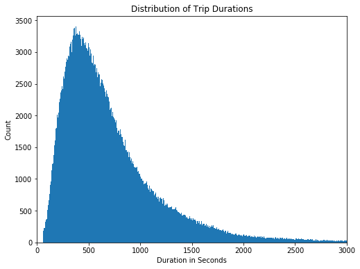

```python
plt.figure(figsize=[8, 6])
bins = np.arange(0, df['duration_sec'].max()+5, 5)
plt.hist(df['duration_sec'], bins=bins);
plt.xlim(0,3000)
plt.title('Distribution of Trip Durations')
plt.xlabel('Duration in Seconds')
plt.ylabel('Count')
```

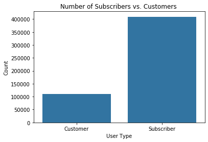

```python
base_color = sb.color_palette()[0]
sb.countplot(data = df, x = 'user_type', color = base_color)
plt.title('Number of Subscribers vs. Customers ')
plt.xlabel('User Type')
plt.ylabel('Count');
```

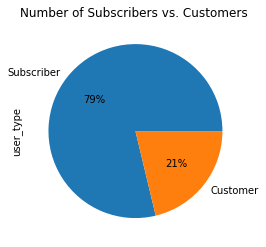

```python
usertype = df.user_type.value_counts()
usertype.plot(kind = 'pie', autopct='%1.0f%%')
plt.title('Number of Subscribers vs. Customers ');
```

> As we can see in the plot above the number of subscribers greatly outnumbers the customers. Which leads me to think that this is because usually there are benefits to being a subscriber and it's cheaper to have a subscription if you enjoy riding bikes.

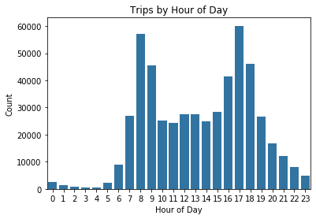

```python
sb.countplot(data=df, x='start_hour', color=base_color);
plt.title('Trips by Hour of Day')
plt.xlabel('Hour of Day');
plt.ylabel('Count');
```

> We can observe here that the most trips are taken in the morning 8-9 or in the evening 17-18.

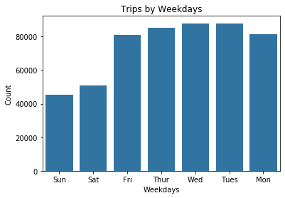

```python
sb.countplot(data=df, x='start_day', color=base_color);
plt.title('Trips by Weekdays')
plt.xlabel('Weekdays');
plt.ylabel('Count');
```

> It is clear that most of rides happened on work days Mon-Fri and the least trips made were on weekends.

### Of the features you investigated, were there any unusual distributions? Did you perform any operations on the data to tidy, adjust, or change the form of the data? If so, why did you do this?

> the dataset i have is clean and tidy. I did not need to adjust too many things the only thing I did is add new columns to the dataset to make it easier to analyze.

## Bivariate Exploration

> In this section, investigate relationships between pairs of variables in your data. Make sure the variables that you cover here have been introduced in some fashion in the previous section (univariate exploration).

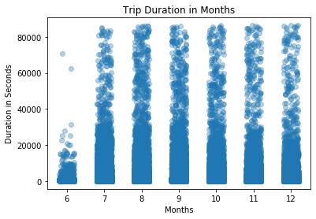

```python
sb.regplot(data = df,x = 'start_month', y = 'duration_sec', fit_reg = False,
           x_jitter = 0.2, y_jitter = 0.2, scatter_kws = {'alpha' : 1/3})
plt.title('Trip Duration in Months')
plt.xlabel('Months')
plt.ylabel('Duration in Seconds')
```

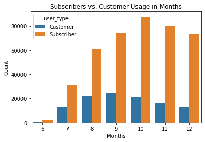

```python
sb.countplot(data=df, x='start_month', hue='user_type');
plt.title('Subscribers vs. Customer Usage in Months')
plt.xlabel('Months');
plt.ylabel('Count');
```

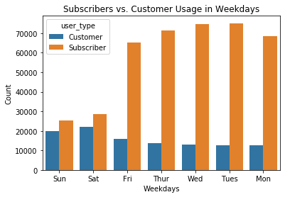

```python
sb.countplot(data=df, x='start_day', hue='user_type');
plt.title('Subscribers vs. Customer Usage in Weekdays')
plt.xlabel('Weekdays');
plt.ylabel('Count');
```

## Multivariate Exploration

> Create plots of three or more variables to investigate your data even further. Make sure that your investigations are justified, and follow from your work in the previous sections.

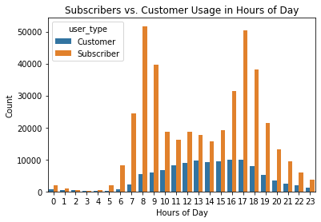

```python
sb.countplot(data=df, x='start_hour', hue='user_type');
plt.title('Subscribers vs. Customer Usage in Hours of Day')
plt.xlabel('Hours of Day');
plt.ylabel('Count');
```

> Subscriber usage is mostly in the moring and evening the could be due to people who work in the morning and getting off work in the evening. Customers tend to ride most in the afternoon or early evening as for a different purpose than the subscriber riders.

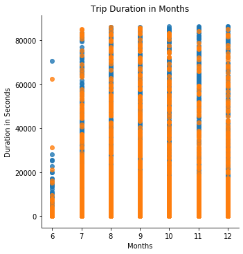

```python
sb.lmplot( x="start_month", y="duration_sec", data=df, fit_reg=False, hue='user_type', legend=False)
plt.title('Trip Duration in Months')
plt.xlabel('Months')
plt.ylabel('Duration in Seconds')
```

> we can conclude that the user-type definitaly does have an impact on trip duration for instance the Customers rent out the bikes for longer trips unlike subscribers.

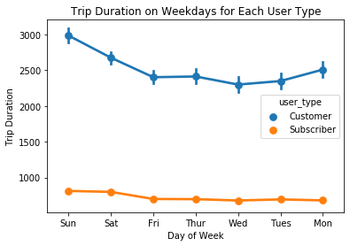

```python
sb.pointplot(data=df, x='start_day', y='duration_sec', hue='user_type');
plt.title('Trip Duration on Weekdays for Each User Type')
plt.xlabel('Day of Week');
plt.ylabel('Trip Duration');
```